# LDA lab

```r
library(dplyr)  # optional
library(ISLR)
library(bestglm)
library(MASS)
library(class)
```

## Data

Standard & Poor’s (S&P) 500 stock market data (`Smarket` in `ISLR` library) contains the daily percentage returns for the S&P 500 stock index between 2001 and 2005.

1. Look at the `help` for details and inspect the data as customarily.

```
'data.frame':   1250 obs. of  9 variables:
 $ Year     : num  2001 2001 2001 2001 2001 ...
 $ Lag1     : num  0.381 0.959 1.032 -0.623 0.614 ...
 $ Lag2     : num  -0.192 0.381 0.959 1.032 -0.623 ...
 $ Lag3     : num  -2.624 -0.192 0.381 0.959 1.032 ...
 $ Lag4     : num  -1.055 -2.624 -0.192 0.381 0.959 ...
 $ Lag5     : num  5.01 -1.055 -2.624 -0.192 0.381 ...
 $ Volume   : num  1.19 1.3 1.41 1.28 1.21 ...
 $ Today    : num  0.959 1.032 -0.623 0.614 0.213 ...
 $ Direction: Factor w/ 2 levels "Down","Up": 2 2 1 2 2 2 1 2 2 2 ...
  Year   Lag1   Lag2   Lag3   Lag4   Lag5 Volume  Today Direction
1 2001  0.381 -0.192 -2.624 -1.055  5.010 1.1913  0.959        Up
2 2001  0.959  0.381 -0.192 -2.624 -1.055 1.2965  1.032        Up
3 2001  1.032  0.959  0.381 -0.192 -2.624 1.4112 -0.623      Down
4 2001 -0.623  1.032  0.959  0.381 -0.192 1.2760  0.614        Up
5 2001  0.614 -0.623  1.032  0.959  0.381 1.2057  0.213        Up
6 2001  0.213  0.614 -0.623  1.032  0.959 1.3491  1.392        Up
      Year           Lag1                Lag2                Lag3
 Min.   :2001   Min.   :-4.922000   Min.   :-4.922000   Min.   :-4.922000
 1st Qu.:2002   1st Qu.:-0.639500   1st Qu.:-0.639500   1st Qu.:-0.640000
 Median :2003   Median : 0.039000   Median : 0.039000   Median : 0.038500
 Mean   :2003   Mean   : 0.003834   Mean   : 0.003919   Mean   : 0.001716
 3rd Qu.:2004   3rd Qu.: 0.596750   3rd Qu.: 0.596750   3rd Qu.: 0.596750
 Max.   :2005   Max.   : 5.733000   Max.   : 5.733000   Max.   : 5.733000
      Lag4                Lag5              Volume           Today
 Min.   :-4.922000   Min.   :-4.92200   Min.   :0.3561   Min.   :-4.922000
 1st Qu.:-0.640000   1st Qu.:-0.64000   1st Qu.:1.2574   1st Qu.:-0.639500
 Median : 0.038500   Median : 0.03850   Median :1.4229   Median : 0.038500
 Mean   : 0.001636   Mean   : 0.00561   Mean   :1.4783   Mean   : 0.003138
 3rd Qu.: 0.596750   3rd Qu.: 0.59700   3rd Qu.:1.6417   3rd Qu.: 0.596750
 Max.   : 5.733000   Max.   : 5.73300   Max.   :3.1525   Max.   : 5.733000
 Direction
 Down:602
 Up  :648
```

The goal is to predict whether the index will increase or decrease on a given day using the past 5 days’ percentage changes in the index.

```r
attach(Smarket)
```

```r
Smarket %>% pairs
```

You can improve the visualization of the scatterplot matrix by using colors for the categorical variable, adding a spline regression, etc.

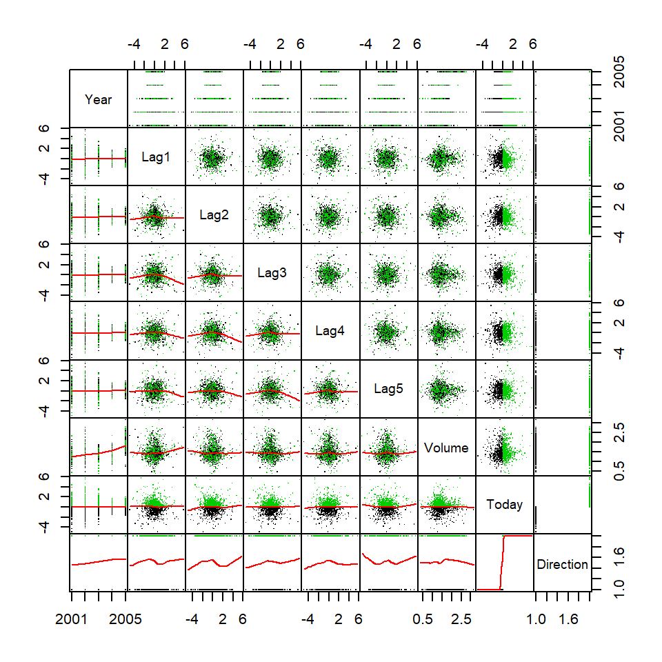

2. There is a derived variable. Which?
3. Do you see a relevant relationship between any couple of variables? Could you expect that?

Ther is just a increasing trend of `Volume` over time.

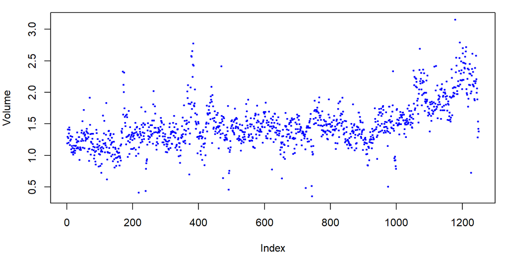

```r
plot(Volume)
```

4. What visualization is more appropriate in order to clearly detect the association (if any) between past changes and current direction?

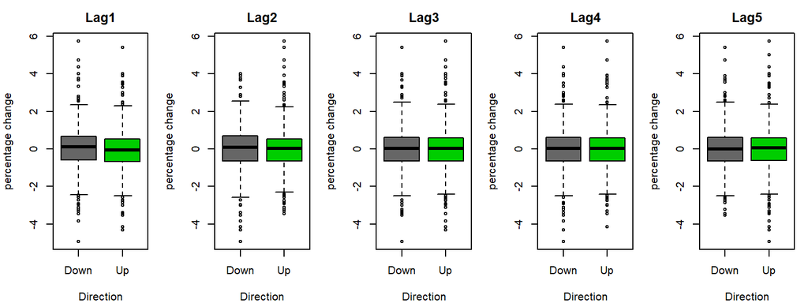

```r
detach(Smarket)
```

## Logistic Regression

We will fit a logistic regression model in order to predict `Direction` using all the `Lag` regressors and the `Volume`.

```r
glm_fit <- glm(Direction ~ . - Today - Year, data = Smarket, family = binomial)
summary(glm_fit)

Call:
glm(formula = Direction ~ . - Today - Year, family = binomial,
    data = Smarket)

Deviance Residuals:
   Min      1Q  Median      3Q     Max
-1.446  -1.203   1.065   1.145   1.326

Coefficients:
             Estimate Std. Error z value Pr(>|z|)
(Intercept) -0.126000   0.240736  -0.523    0.601
Lag1        -0.073074   0.050167  -1.457    0.145
Lag2        -0.042301   0.050086  -0.845    0.398
Lag3         0.011085   0.049939   0.222    0.824
Lag4         0.009359   0.049974   0.187    0.851
Lag5         0.010313   0.049511   0.208    0.835
Volume       0.135441   0.158360   0.855    0.392

(Dispersion parameter for binomial family taken to be 1)

    Null deviance: 1731.2  on 1249  degrees of freedom
Residual deviance: 1727.6  on 1243  degrees of freedom
AIC: 1741.6

Number of Fisher Scoring iterations: 3
```

5. Is there any significant coefficient? Are you surprised of the result? Anyhow, is there any practical advice?

However, we can use the model to make predictions.

```r
glm_probs <- predict(glm_fit, type = "response")
```

E.g., predictions (for `Up` or `Down`?) for the oldest 10 days are:

```
        1         2         3         4         5         6         7         8
0.5070841 0.4814679 0.4811388 0.5152224 0.5107812 0.5069565 0.4926509 0.5092292
        9        10
0.5176135 0.4888378
     Up
Down  0
Up    1
```

Not all that surprising! $\ldots$

We can turn these probabilities into classifications. Let the threshold be $0.5$

```r
glm_pred <- ifelse(..., "Up", "Down")
```

We can now compute the confusion matrix and from this the error rate.

```
glm_pred Down  Up
    Down  145 141
    Up    457 507
[1] 0.4784
```

it appears that the logistic regression model is working slightly better than chance. However this corresponds to the training error rate. Instead, we need the test counterpart!

Then, we divide data into training and test data, refit the model and calculated the test error rate.

```r
train <- Smarket$Year < 2005
glm_fit_0104 <- glm(Direction ~ . - Today - Year, data = Smarket, family = binomial, subset = train)
glm_probs_05 <- predict(glm_fit_0104, Smarket[!train, ], type = "response")
glm_pred_05 <- ifelse(glm_probs_05 > 0.5, "Up", "Down")
table(glm_pred_05, Smarket$Direction[!train])

glm_pred_05 Down Up
       Down   77 97
       Up     34 44
mean(glm_pred_05 != Smarket$Direction[!train])
[1] 0.5198413
```

On test data, We are doing worse than chance.

6. One reason can be overfitting. Why?

### Best subset

Let consider a bit simpler model. 7) From a best subset selection we obtain that the best model with at least two predictors is the one with `Lag1` and `Lag2`:

```
   Lag1  Lag2  Lag3  Lag4  Lag5 Volume Criterion
1 FALSE FALSE FALSE FALSE FALSE  FALSE  1731.175
2  TRUE FALSE FALSE FALSE FALSE  FALSE  1731.197
3  TRUE  TRUE FALSE FALSE FALSE  FALSE  1732.403
4  TRUE FALSE FALSE FALSE FALSE   TRUE  1732.437
5 FALSE  TRUE FALSE FALSE FALSE  FALSE  1732.450
```

```r
glm_fit_2 <- glm(Direction ~ Lag1 + Lag2, data = Smarket, family = binomial, subset = train)
```

8. As before, after calculated the predicted probabilities and derived classes for the test data, the confusion matrix and the test error rate are:

```
glm_pred_2 Down  Up
      Down   35  35
      Up     76 106
[1] 0.4404762
```

Now the results appear to be a little better.

9. But, what if we would have used a *naive Bayes* method?

```
     Down  Up
  Up  111 141
[1] 0.4404762
```

Mmmmh!

## KNN

Read the `help` on `knn` and create the appropriate inputs for the routine. Consider just the `Lag1` and `Lag2` as predictors.

```r
attach(Smarket)

train_X <- cbind(Lag1, Lag2)[train, ]
test_X <- cbind(Lag1, Lag2)[!train, ]
train_Direction <- Direction[train]
```

To ensure the reproducibility of results:

```r
set.seed(2)
```

```r
knn_pred <- knn(train_X, test_X, train_Direction, k = 1)
table(knn_pred, Direction[!train])

knn_pred Down Up
    Down   43 58
    Up     68 83
mean(knn_pred != Direction[!train])
[1] 0.5
```

### Search for the best $K$

10. Try $\,k$ from 1 to $10$ and plot the results.

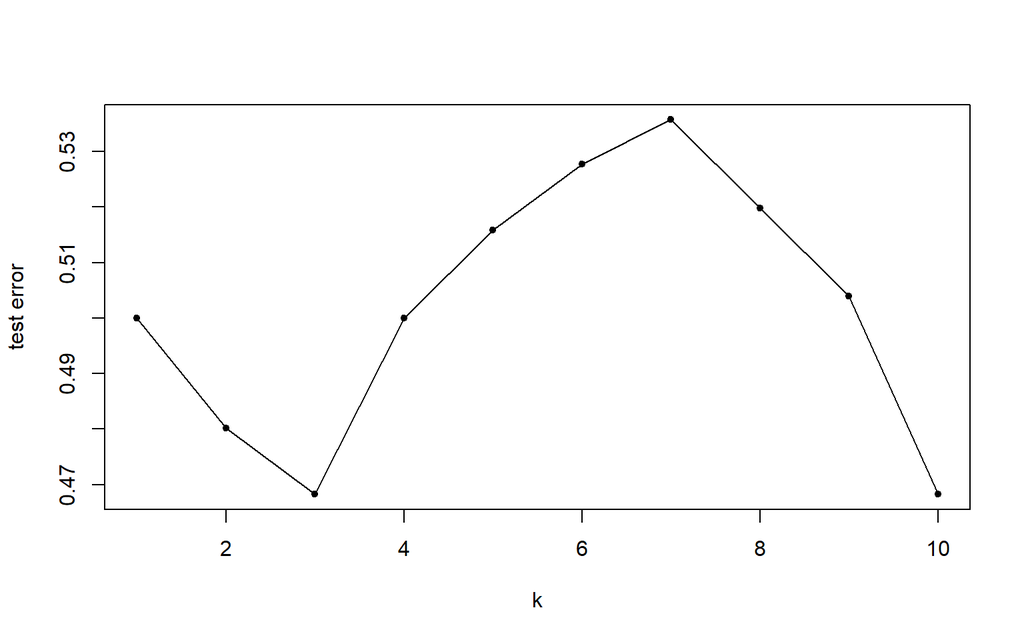

Below $100$ replications with the mean superimposed.

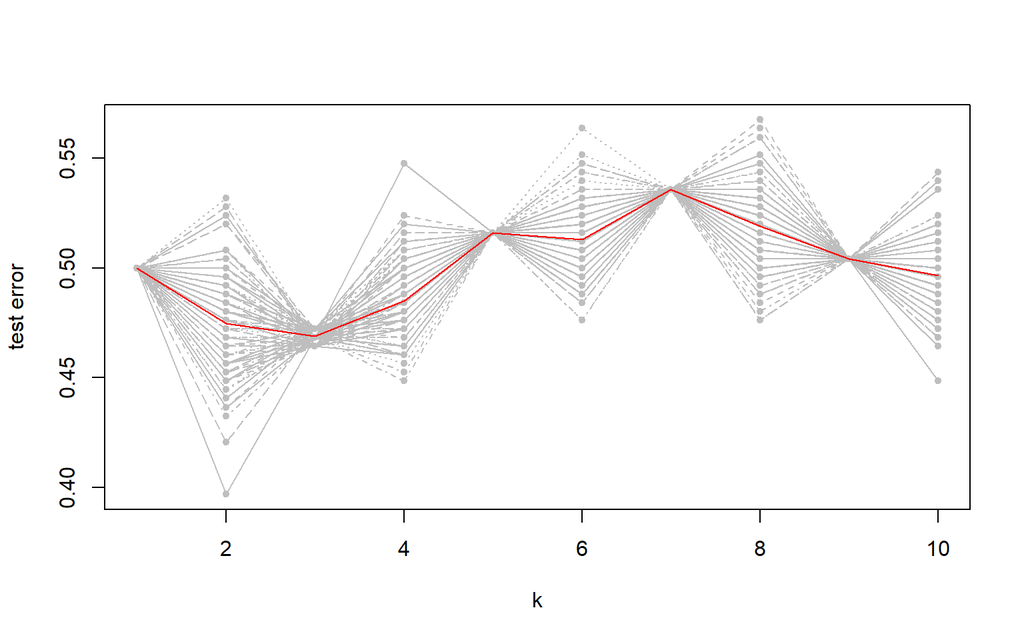

```
k with min mean (test) error is 3(0.469)
```

```r
detach(Smarket)
```

## Discriminant Analysis

### LDA

We continue by fitting an LDA model on the training set still with the sole `Lag1` and `Lag2` as predictors.

```r
lda_fit <- lda(Direction ~ Lag1 + Lag2, data = Smarket, subset = train)
lda_fit
Call:
lda(Direction ~ Lag1 + Lag2, data = Smarket, subset = train)

Prior probabilities of groups:
    Down       Up
0.491984 0.508016

Group means:
            Lag1        Lag2
Down  0.04279022  0.03389409
Up   -0.03954635 -0.03132544

Coefficients of linear discriminants:
            LD1
Lag1 -0.6420190
Lag2 -0.5135293
```

11. What are the prior probabilities? What do the `Group means` in the output consist of?

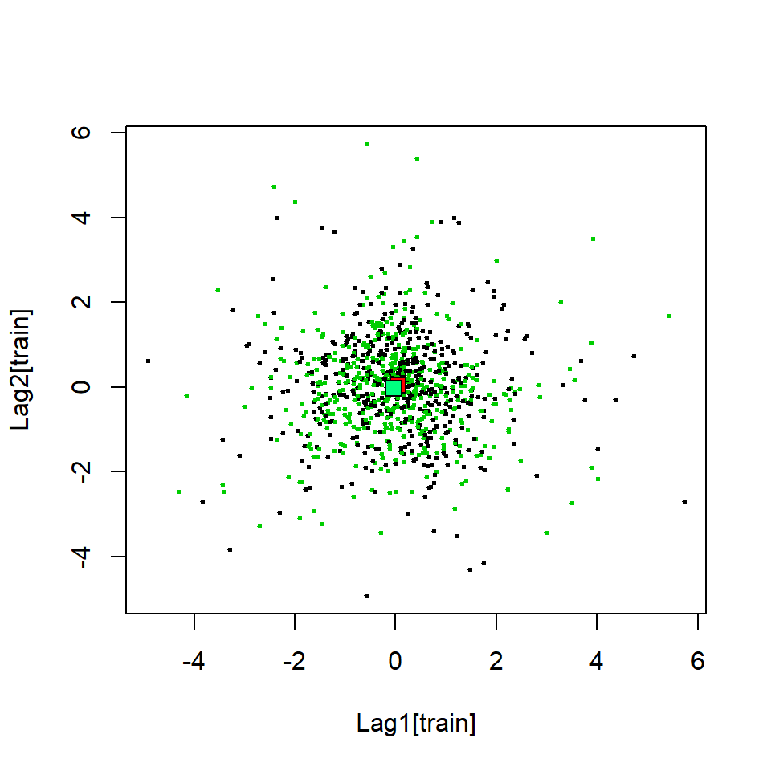

The `Coeffs of Linear discriminants` are used to compute the decision boundary. The `plot` shows the distribution of the linear combination of the variables for the two groups.

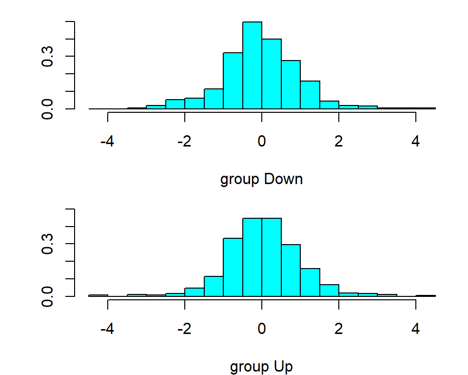

```r
plot(lda_fit)
```

The use of `predict` is analogous to previous techniques. The output components are:

```r
lda_pred <- predict(lda_fit, Smarket[!train, ])
names(lda_pred)
[1] "class"     "posterior" "x"
List of 3
 $ class    : Factor w/ 2 levels "Down","Up": 2 2 2 2 2 2 2 2 2 2 ...
 $ posterior: num [1:252, 1:2] 0.49 0.479 0.467 0.474 0.493 ...
  ..- attr(*, "dimnames")=List of 2
  .. ..$ : chr [1:252] "999" "1000" "1001" "1002" ...
  .. ..$ : chr [1:2] "Down" "Up"
 $ x        : num [1:252, 1] 0.0829 0.5911 1.1672 0.8334 -0.0379 ...
  ..- attr(*, "dimnames")=List of 2
  .. ..$ : chr [1:252] "999" "1000" "1001" "1002" ...
  .. ..$ : chr "LD1"
  class posterior.Down posterior.Up         LD1
1  Down      0.5017497    0.4982503 -0.45308190
2  Down      0.5070782    0.4929218 -0.69992532
3  Down      0.5108497    0.4891503 -0.87468428
4    Up      0.4842383    0.5157617  0.35830426
5    Up      0.4922853    0.5077147 -0.01465422
6    Up      0.4806852    0.5193148  0.52309216
```

12. How the `class` has been obtained?

LDA performance on the test set (predicted by row):

```
       Down  Up
  Down   35  35
  Up     76 106
[1] 0.4404762
```

Did you expect that?

13. Suppose that you wish to predict a market increase only if you are very certain that the market will indeed increase on that day. How do you use the fitted model?

### QDA

We end by fitting a QDA by means of `qda` (in `MASS` library).

```r
qda_fit <- qda(Direction ~ Lag1 + Lag2, data = Smarket, subset = train)
qda_fit
Call:
qda(Direction ~ Lag1 + Lag2, data = Smarket, subset = train)

Prior probabilities of groups:
    Down       Up
0.491984 0.508016

Group means:
            Lag1        Lag2
Down  0.04279022  0.03389409
Up   -0.03954635 -0.03132544
```

```r
qda_class <- predict(qda_fit, Smarket[!train, ])$class
table(qda_class, Smarket$Direction[!train])

qda_class Down  Up
     Down   30  20
     Up     81 121
mean(qda_class != Smarket$Direction[!train])
[1] 0.4007937
```

In the end, what is the best classifier for this data?

Matilde Trevisani

2018-11-26